# Week 8 GLM Practical Notes

```r
library(tidyverse)

library(MASS)

library(GGally)
library(patchwork)

library(rsq)

pub <- read.csv("Data/pub.csv")
# Setting female and married as factors
pub <- pub %>%
  mutate(across(2:3, as.factor))
```

# Exploratory analysis

## Summary

First, a basic summary of the data. We look for any possible indication of data errors.

```r
summary(pub)
```

```
    articles      female  married      kids           prestige         mentor
 Min.   : 0.000   0:494   0:309   Min.   :0.0000   Min.   :0.755   Min.   : 0.000
 1st Qu.: 0.000   1:421   1:606   1st Qu.:0.0000   1st Qu.:2.260   1st Qu.: 3.000
 Median : 1.000                   Median :0.0000   Median :3.150   Median : 6.000
 Mean   : 1.693                   Mean   :0.4951   Mean   :3.103   Mean   : 8.767
 3rd Qu.: 2.000                   3rd Qu.:1.0000   3rd Qu.:3.920   3rd Qu.:12.000
 Max.   :19.000                   Max.   :3.0000   Max.   :4.620   Max.   :77.000
```

There are some values that appear to be quite high for mentor and articles, but when we look at the overall distribution we see that it is very skewed and so these values are probably not a cause for concern at the moment.

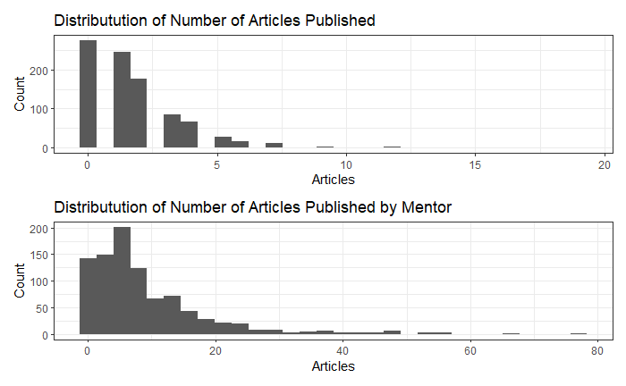

```r
articles_histogram <- pub %>%
  ggplot(aes(x = articles)) +
  geom_histogram() +
  theme_bw() +
  labs(title = "Distributution of Number of Articles Published",
       x = "Articles",
       y = "Count")

mentor_histogram<- pub %>%
  ggplot(aes(x = mentor)) +
  geom_histogram() +
  theme_bw() +
  labs(title = "Distributution of Number of Articles Published by Mentor",
       x = "Articles",
       y = "Count")

articles_histogram / mentor_histogram
```

## Pairs plot

A quick look at all the possible associations between the variables:

```r
pairs(pub)
```

[output not shown]

There are obvious relationships between some of the explanatory variables. Marriage means higher numbers of kids.The prestige of the program is positively correlated with the output of the mentor.

## Boxplots

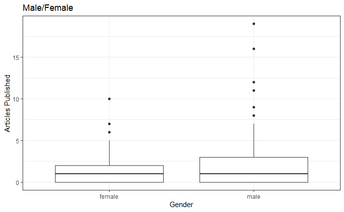

```r
female_boxplot <- pub %>%
  mutate(female = ifelse(female == 0, "male", "female")) %>%
  ggplot() +
  geom_boxplot(aes(x = female, y = articles)) +
  theme_bw() +
  labs(title = "Male/Female",
       x = "Gender",
       y = "Articles Published")

female_boxplot
```

We see that the median number of publications is similar for men and women but that there is a larger dispersion for the number of articles produced by men.

```r
mean_articles_f <- pub %>%
  group_by(female) %>%
  summarise(mean = mean(articles)) %>%
  mutate(mean = signif(mean,3))
mean_articles_f
```

| female | mean |
| --- | --- |
| 0 | 1.88 |
| 1 | 1.47 |

The mean number of articles is lower for women however.

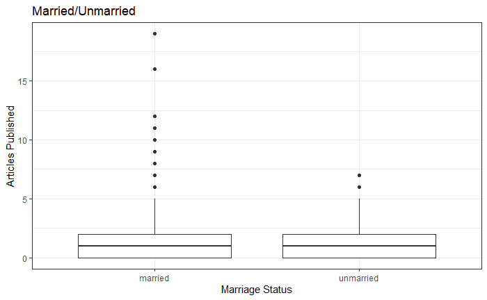

```r
married_boxplot <- pub %>%
  mutate(married = ifelse(married == 1,"married","unmarried")) %>%
  ggplot() +
  geom_boxplot(aes(x = married, y = articles)) +
  theme_bw() +
  labs(title = "Married/Unmarried",
       x = "Marriage Status",
       y = "Articles Published")

married_boxplot
```

Larger spread for people who are married but again similar median.

```r
mean_articles_married <- pub %>%
  group_by(married) %>%
  summarise(mean = mean(articles)) %>%
  mutate(mean = signif(mean,3))

mean_articles_married
```

| married | mean |
| --- | --- |
| 0 | 1.59 |
| 1 | 1.74 |

Married people have a higher mean output, but the difference is smaller.

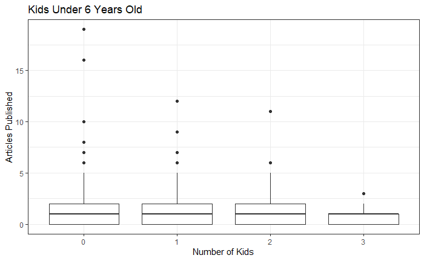

```r
kids_boxplot <- pub %>%
  ggplot() +
  geom_boxplot(aes(x = as.factor(kids), y = articles)) +
  theme_bw() +
  labs(title = "Kids Under 6 Years Old",
       x = "Number of Kids",
       y = "Articles Published")

kids_boxplot
```

Larger spread of articles for individuals with fewer children.

```r
mean_articles_kids <- pub %>%
  group_by(kids) %>%
  summarise(mean = mean(articles)) %>%
  mutate(mean = signif(mean,3))

mean_articles_kids
```

| kids | mean |
| --- | --- |
| 0 | 1.720 |
| 1 | 1.760 |
| 2 | 1.540 |
| 3 | 0.812 |

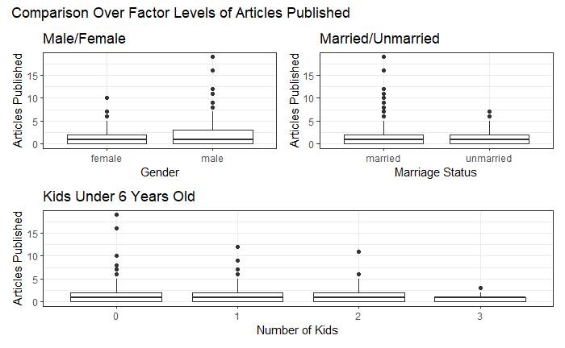

```r
(female_boxplot + married_boxplot) / kids_boxplot +
  plot_annotation(
    title = "Comparison Over Factor Levels of Articles Published"
  )
```

Highest output from individuals with one child, then the number of articles drops off. Since the relationship between number of kids and articles is not monotonic, it is probably best to treat the number of children as a factor.

```r
write.table(mean_articles_kids,"mean_articles_kids.text",
          quote = F,
          row.names = F)
```

```r
prestige_points <- pub %>%
  ggplot(aes(x = prestige, y = articles)) +
  geom_point(alpha = 0.5, color = "blue") +
  theme_bw() +
  labs(title = "Number of Articles Published vs Prestige",
       x = "Prestige", y = "Articles Published")
```

[figure not shown]

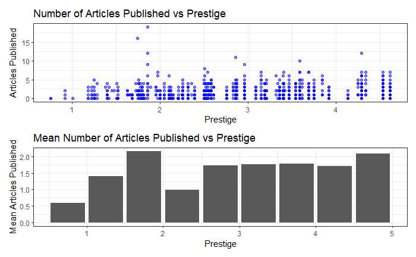

```r
prestige_points / prestige_colplot
```

[output not shown]

Grouping prestige into 0.5 unit increments and taking the mean we see that the mean number of publications seems to increase slightly with prestige.

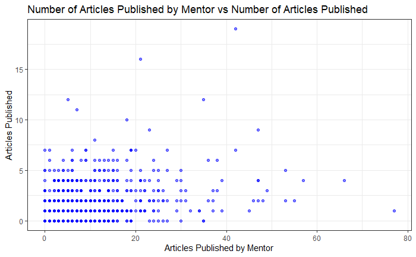

```r
mentor_points <- pub %>%
  ggplot(aes(x = mentor, y = articles)) +
  geom_point(alpha = 0.5, color = "blue") +
  theme_bw() +
  labs(title = "Number of Articles Published by Mentor vs Number of Articles Published",
       x = "Articles Published by Mentor", y = "Articles Published")
mentor_points
```

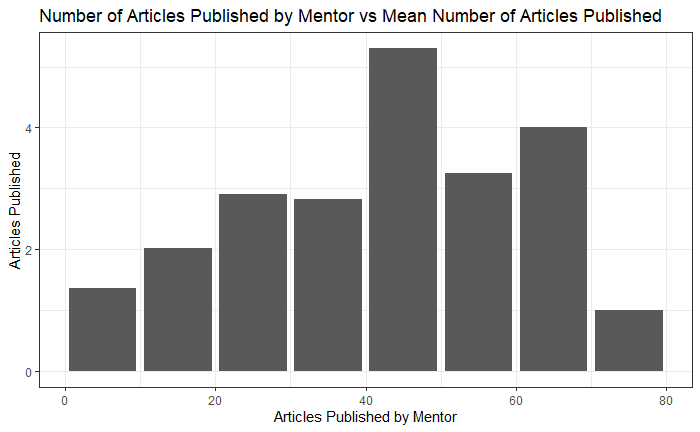

```r
mentor_colplot <- pub %>%
  mutate(mentor = floor(mentor/10)*10 + 5) %>%
  group_by(mentor) %>%
  summarise(mean = mean(articles)) %>%
  ggplot(aes(x = mentor, y = mean)) +
  geom_col() +
  theme_bw() +
  labs(title = "Number of Articles Published by Mentor vs Mean Number of Articles Published",
       x = "Articles Published by Mentor", y = "Articles Published")
mentor_colplot
```

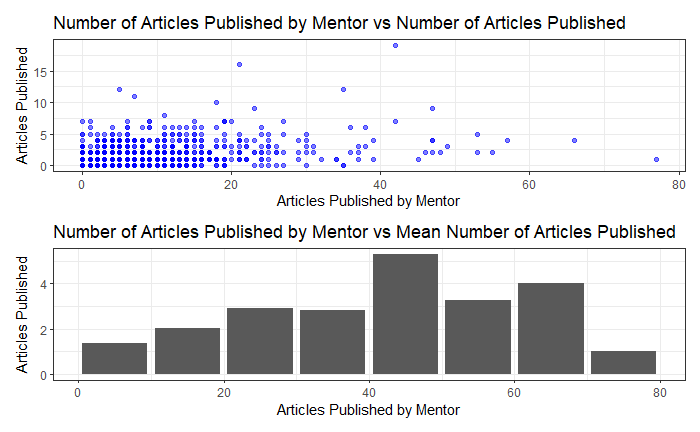

```r
mentor_points / mentor_colplot
```

Grouping the number of articles published by mentors into intervals of 10 articles, there appears to be some positive relationship between the mean number of articles produced by PhD candidates and output of their mentors but the relationship is not particularly clear. There is also very sparse data at the end of the series.

```r
pub$kids <- as.factor(pub$kids)
```

# Model Fitting

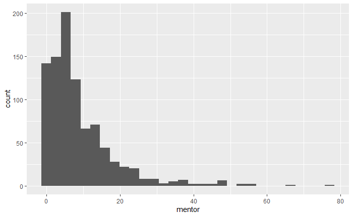

```r
pub %>%
  ggplot(aes(x = mentor)) +
  geom_histogram()
```

## AIC model selection

```r
# Null model
pub.glm.null <- glm(articles ~ 1,
               data = pub,
               family = poisson)

stepAIC(pub.glm.null,
        scope = list(lower = pub.glm.null, upper = pub.glm),
        data = pub,
        direction = "forward")
```

```
Start:  AIC=3487.15
articles ~ 1

           Df Deviance    AIC
+ mentor    1   1669.5 3341.3
+ female    1   1794.4 3466.1
+ prestige  1   1806.6 3478.3
+ kids      3   1806.1 3481.8
+ married   1   1814.6 3486.3
<none>          1817.4 3487.1

Step:  AIC=3341.29
articles ~ mentor

           Df Deviance    AIC
+ female    1   1657.0 3330.7
+ kids      3   1658.6 3336.4
<none>          1669.5 3341.3
+ married   1   1667.6 3341.4
+ prestige  1   1669.3 3343.1

Step:  AIC=3330.74
articles ~ mentor + female

                Df Deviance    AIC
+ kids           3   1638.9 3318.6
<none>               1657.0 3330.7
+ married        1   1656.7 3332.4
+ prestige       1   1656.8 3332.6
+ female:mentor  1   1657.0 3332.7

Step:  AIC=3318.64
articles ~ mentor + female + kids

                Df Deviance    AIC
+ married        1   1633.3 3315.1
<none>               1638.9 3318.6
+ female:mentor  1   1638.8 3320.5
+ prestige       1   1638.8 3320.6
+ female:kids    3   1637.6 3323.3

Step:  AIC=3315.07
articles ~ mentor + female + kids + married

                 Df Deviance    AIC
<none>                1633.3 3315.1
+ female:married  1   1633.1 3316.8
+ prestige        1   1633.1 3316.8
+ female:mentor   1   1633.2 3317.0
+ female:kids     3   1632.0 3319.8

Call:  glm(formula = articles ~ mentor + female + kids + married, family = poisson,
    data = pub)

Coefficients:
(Intercept)       mentor      female1        kids1        kids2        kids3     married1
    0.34765      0.02557     -0.22597     -0.18031     -0.32775     -0.82152      0.14812

Degrees of Freedom: 914 Total (i.e. Null);  908 Residual
Null Deviance:      1817
Residual Deviance: 1633     AIC: 3315
```

```r
#Saving AIC score
write.table(
  round(AIC(glm(articles ~ 1 + female + married + kids + mentor,
               data = pub,
               family = poisson)),1),
  file = "AIC_score_forward_selection.text",
  row.names = F
)
```

Using forward selection we get the formula: articles ~ mentor + female + kids + married.

```r
stepAIC(pub.glm,
        scope = list(lower = pub.glm.null, upper = pub.glm),
        data = pub,
        direction = "backward")
```

```
Start:  AIC=3321.36
articles ~ 1 + female + married + kids + prestige + mentor +
    female * (married + kids + prestige + mentor)

                  Df Deviance    AIC
- female:kids      3   1626.9 3316.6
- female:mentor    1   1625.7 3319.4
- female:married   1   1626.1 3319.9
<none>                 1625.6 3321.4
- female:prestige  1   1631.4 3325.2

Step:  AIC=3316.64
articles ~ female + married + kids + prestige + mentor + female:married +
    female:prestige + female:mentor

                  Df Deviance    AIC
- female:mentor    1   1627.0 3314.8
- female:married   1   1627.3 3315.0
<none>                 1626.9 3316.6
- female:prestige  1   1632.8 3320.6
- kids             3   1649.0 3332.7

Step:  AIC=3314.79
articles ~ female + married + kids + prestige + mentor + female:married +
    female:prestige

                  Df Deviance    AIC
- female:married   1   1627.4 3313.2
<none>                 1627.0 3314.8
- female:prestige  1   1632.9 3318.6
- kids             3   1649.3 3331.0
- mentor           1   1757.2 3442.9

Step:  AIC=3313.18
articles ~ female + married + kids + prestige + mentor + female:prestige

                  Df Deviance    AIC
<none>                 1627.4 3313.2
- married          1   1632.2 3316.0
- female:prestige  1   1633.1 3316.8
- kids             3   1651.0 3330.8
- mentor           1   1757.5 3441.2

Call:  glm(formula = articles ~ female + married + kids + prestige +
    mentor + female:prestige, family = poisson, data = pub)

Coefficients:
     (Intercept)           female1          married1             kids1             kids2             kids3
         0.47391          -0.63170           0.13862          -0.18735          -0.32483          -0.82756
        prestige            mentor  female1:prestige
        -0.03619           0.02542           0.12655

Degrees of Freedom: 914 Total (i.e. Null);  906 Residual
Null Deviance:      1817
Residual Deviance: 1627     AIC: 3313
```

Using backward selection, the formula selected is:

articles ~ female + married + kids + prestige + mentor + female:prestige.

```r
stepAIC(pub.glm.null,
        scope = list(lower = pub.glm.null, upper = pub.glm),
        data = pub,
        direction = "both")
```

```
Start:  AIC=3487.15
articles ~ 1

           Df Deviance    AIC
+ mentor    1   1669.5 3341.3
+ female    1   1794.4 3466.1
+ prestige  1   1806.6 3478.3
+ kids      3   1806.1 3481.8
+ married   1   1814.6 3486.3
<none>          1817.4 3487.1

Step:  AIC=3341.29
articles ~ mentor

           Df Deviance    AIC
+ female    1   1657.0 3330.7
+ kids      3   1658.6 3336.4
<none>          1669.5 3341.3
+ married   1   1667.6 3341.4
+ prestige  1   1669.3 3343.1
- mentor    1   1817.4 3487.1

Step:  AIC=3330.74
articles ~ mentor + female

                Df Deviance    AIC
+ kids           3   1638.9 3318.6
<none>               1657.0 3330.7
+ married        1   1656.7 3332.4
+ prestige       1   1656.8 3332.6
+ female:mentor  1   1657.0 3332.7
- female         1   1669.5 3341.3
- mentor         1   1794.4 3466.1

Step:  AIC=3318.64
articles ~ mentor + female + kids

                Df Deviance    AIC
+ married        1   1633.3 3315.1
<none>               1638.9 3318.6
```

[output cut: 16 more lines]

```
+ female:kids     3   1632.0 3319.8
- female          1   1650.5 3330.3
- kids            3   1656.7 3332.4
- mentor          1   1772.5 3452.2

Call:  glm(formula = articles ~ mentor + female + kids + married, family = poisson,
    data = pub)

Coefficients:
(Intercept)       mentor      female1        kids1        kids2        kids3     married1
    0.34765      0.02557     -0.22597     -0.18031     -0.32775     -0.82152      0.14812

Degrees of Freedom: 914 Total (i.e. Null);  908 Residual
Null Deviance:      1817
Residual Deviance: 1633     AIC: 3315
```

```r
#Saving AIC score
write.table(
  round(AIC(glm(formula = articles ~ female + married + kids + prestige +
    mentor + female:prestige, family = poisson, data = pub)),1),
  file = "AIC_score_backward_selection.text",
  row.names = F
)
```

So the question, how do we select between these models?

Test for inclusion of prestige

```r
pub.glm.noprestige <- glm(articles ~ 1 + female + married + kids + mentor,
               data = pub,
               family = poisson)
pub.glm.prestige <- glm(articles ~ 1 + female + married + kids + mentor + prestige,
               data = pub,
               family = poisson)
dof <- pub.glm.prestige$rank - pub.glm.noprestige$rank
lrt <- deviance (pub.glm.noprestige) - deviance(pub.glm.prestige)
pval <- 1 - pchisq(lrt,dof)
cbind(lrt,dof,pval)
```

```
           lrt dof      pval
[1,] 0.2325111   1 0.6296681
```

```r
write.table(
  signif(cbind(lrt,dof,pval),3),
  file = "hypothesis_test1.text",
  row.names = F
)
```

Just including prestige is not significant.

```r
pub.glm.noprestige <- glm(articles ~ 1 + female + married + kids + mentor,
               data = pub,
               family = poisson)
pub.glm.prestige <- glm(articles ~ 1 + female + married + kids + mentor + prestige + female*prestige,
               data = pub,
               family = poisson)
dof <- pub.glm.prestige$rank - pub.glm.noprestige$rank
lrt <- deviance (pub.glm.noprestige) - deviance(pub.glm.prestige)
pval <- 1 - pchisq(lrt,dof)
cbind(lrt,dof,pval)
```

```
          lrt dof       pval
[1,] 5.893019   2 0.05252273
```

```r
write.table(
  signif(cbind(lrt,dof,pval),3),
  file = "hypothesis_test2.text",
  row.names = F
)
```

The hypothesis test suggests that there is a significant effect for including both prestige and female at the 10% significance level.

Let us include the prestige and female*prestige term since it has a borderline significant effect which we may want to examine in our analysis.

Marriage may not be significant, so let us test for it:

```r
pub.glm.nomarriage <- glm(articles ~ 1 + female + kids + mentor,
               data = pub,
               family = poisson)
pub.glm.marriage <- glm(articles ~ 1 + female + married + kids + mentor,
               data = pub,
               family = poisson)
dof <- pub.glm.marriage$rank - pub.glm.nomarriage$rank
lrt <- deviance (pub.glm.nomarriage) - deviance(pub.glm.marriage)
pval <- 1 - pchisq(lrt,dof)
cbind(lrt,dof,pval)
```

```
          lrt dof       pval
[1,] 5.571698   1 0.01825305
```

```r
write.table(
  signif(cbind(lrt,dof,pval),3),
  file = "hypothesis_test3.text",
  row.names = F
)
```

Final model:

```r
pub.glm.selected <- glm(articles ~ 1 + female + married + kids + mentor + prestige + female*prestige,
               data = pub,
               family = poisson)
```